# 🎾 **Tennis Prediction** 🎾

[figure not shown]

## **Table of Contents of the notebook**

- I. 🎾 Understand Tennis
- II. 🏗️ Data Preparation Process
- III. 🔎 Observation
- IV. 📈 Features selection & 🤖 Modeling Phase
- V. 🚀 Further improvements

## **I.** 🎾 **Understand Tennis**

### **The Framework**

Each tennis match is made up of two to three sets. To win a set, you must win at least six games. The games are scored starting at "love" (or zero) and go up to 40, but that's actually just four points. From love, the first point is 15, then 30, then 40, then game point, which wins the game.

### **Starting the Game**

To determine who serves first, you flip a coin or (more likely) spin a racket. Whoever wins the toss gets to decide one of four things: that she wants to serve first, that she wants to receive first, which side of the court she wants to start on (in which case, the opponent chooses who serves first), or that she wants to leave the choices up to her opponent. Whoever starts serving continues to serve until that game is over. Then the serve moves to the other player. You serve from behind the baseline, starting on the right-hand side of the court, anywhere between the singles sideline and the centre mark on the court.

### **Scoring the Game**

Before serving, you should announce the score, with your score first, then your opponent's. So if you have zero and your opponent has 30, say "love-30." Every time you serve, you get two tries. The serve must go over the net, land in the service box opposite you, and bounce once before your opponent returns it. If it doesn't land in the service box, you take a second serve. If the second serve also misses (a double fault), then you lose the point. If your serve grazes the net but still lands in the service box, the serve doesn't count, and you must take that serve over. This is called a "let." If your serve goes in and the opponent returns it, you continue hitting back and forth until someone hits the ball into the net, hits it out of bounds, or misses a shot. If that person is you, then your opponent gets a point. If it's your opponent who hits it into the net/hits it out of bounds/misses a shot, then you get the point. Whoever is serving continues serving until the score reaches 40, calling out the score before every serve. If the score is tied at 40 ("40-all"), that is "deuce," which is essentially another word for tie. To break the tie, someone must win two points in a row. If you are serving at deuce and you win the next point, you get and "advantage". If your opponent wins, it goes back to deuce, and someone again must win by two points in a row. Yes, this could go on forever. Once the game is over, the other person serves. After odd-numbered games (so after game one, game three, game five) you switch sides on the court.

### **Scoring a Set**

Before the first serve in each new game, whoever is serving announces the score in sets. Say your score first, then your opponent's. So if you won the first set, you would say "1-0." To complete a set, someone must win six games; the first person to win six games wins the set. However, as with "deuce," you must win a set by at least two games. So, if the score is 6-5, the person with 5 must win by two games. If the score ties at 6-6, you play a tiebreaker.

### **Scoring the Match**

The whole shebang is called a match. The match is determined by the best two out of three sets. So if you win two sets, you win. If you each win a set, then you play a third set to determine the winner.

### **POINT SYSTEM**

Tennis has a different point system than most sports. Before we go into detail, here is your guide to scoring a game:

- 0 points= Love
- 1 point = 15
- 2 points= 30
- 3 points= 40
- Tied score= All
- 40-40 = Deuce
- Server wins deuce point = Ad-In
- Receiver wins deuce point = Ad-Out

### **Tennis Scoring Cheat Sheet**

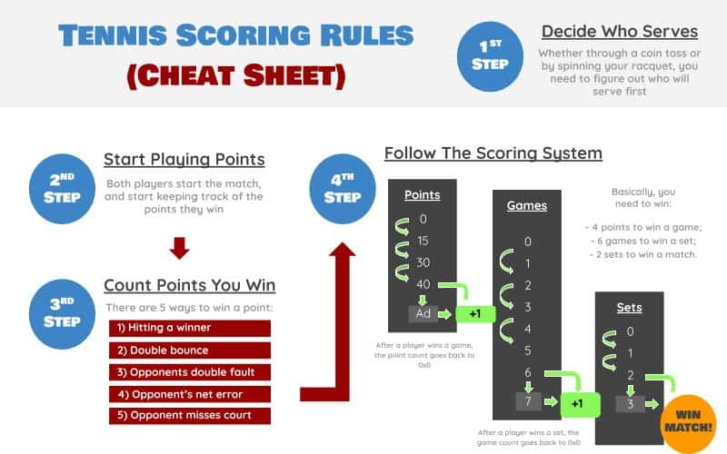

### Place of the Serve

##### **The Three Areas**

- **Wide** – to serve out wide is very popular especially in singles tennis, by serving in this direction it opens up the court as it makes your opponent run to the ball. However, it does give your opponent more options for his return. If you are playing doubles tennis by serving out wide it give your partner a good opportunity to approach the net and anticipate the return.
- **Down the T** – if you prefer playing percentage tennis then serving “down the T” or in the middle does not give your opponent as many angles to hit their service return. By serving down the middle it can limit any cross court returns, and in doubles that gives your partner an opportunity to get into the point. The only real risk of this serve it is quite a small area you are aiming for.
- **Into the Body** – a really effective serve in singles and doubles as it ties your opponent up and does not allow him time to do little but get the ball back. In singles and doubles it often causes short returns therefore setting the server side up for a volley on their next shot. For the server it makes the service easier to produce as there is a bigger area to aim for.

## **Modeling A Game In Tennis (Markov Chain)**

I find That the best way to represent a Tennis Game in Mathematique way is to use a Markov chain, Let assume we have Player A and Player B, where Player A is serving in Game(n):

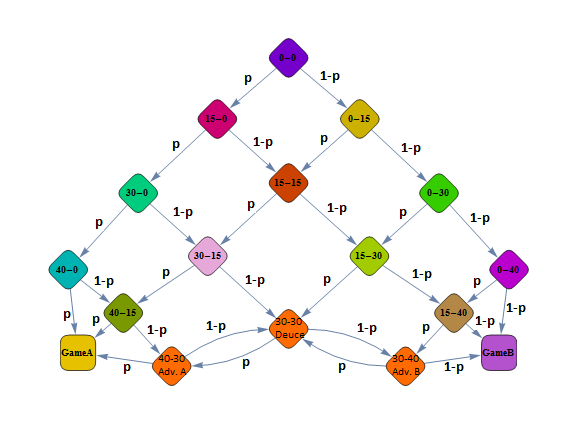

We can clearly begin to work out some mathematical formulae now. If we solely care about the chances of Player A winning his service game, there are four possible outcomes: 40-0, 40-15, 40-30, and Adv-40:

![image.png](https://tobykingsman.files.wordpress.com/2016/02/eqn.png)

Holding serve to **love (0)** requires that Player A wins the first four points in a row, so the probability of winning the game in this case is:

![image.png](https://s0.wp.com/latex.php?latex=%5Ctext%7BProb%28Hold+serve+to+0%29%7D+%3D+p%5E4+&bg=ffffff&fg=808080&s=0&c=20201002)

Holding serve to **15** requires Player A to win three of the first four points, as well as the fifth point. This indicates that the solution is related to the binomial theorem and binomial coefficients. We need to increase the formula by four since Player A can hold serve to 15 in four distinct ways (i.e., Player B can win the first, second, third, or fourth point):

![image.png](https://s0.wp.com/latex.php?latex=%5Ctext%7BProb%28Hold+serve+to+15%29%7D+%3D+%7B4+%5Cchoose+1%7D+p%5E4%281-p%29+%3D+4p%5E4%281-p%29+&bg=ffffff&fg=808080&s=0&c=20201002)

In a similar vein, we may calculate that Player A must win 3 of the first 5 points and the 6th point to hold serve to **30**. As a result, in this example, the probability is:

![image.png](https://s0.wp.com/latex.php?latex=%5Ctext%7BProb%28Hold+serve+to+30%29%7D+%3D+%7B5+%5Cchoose+2%7D+p%5E4%281-p%29%5E2+%3D+10p%5E4%281-p%29%5E2+&bg=ffffff&fg=808080&s=0&c=20201002)

The last possibility to explore is what occurs if we go to **deuce**. As seen in the figure, here is where things start to become tricky, because we may wind ourselves in an infinite loop where the game never ends. Player A and Player B must each win three points out of the first six games to reach deuce for the first time. As a result, the likelihood of reaching the first deuce is:

![image.png](https://s0.wp.com/latex.php?latex=%5Ctext%7BProb%28Reach+deuce%29%7D+%3D+%7B6+%5Cchoose+3%7D+p%5E3%281-p%29%5E3+%3D+20p%5E3%281-p%29%5E3+&bg=ffffff&fg=808080&s=0&c=20201002)

From the initial deuce circumstance and all subsequent deuce situations, Player A must now win two points in a row to win the game. **Future deuces** occur when both players have won one point respectively, and either Player A or Player B wins the next point, or vice versa. As a result, the chance of winning from a deuce can be written as :

![image.png](https://s0.wp.com/latex.php?latex=%5Ctext%7BProb%28Hold+serve+via+deuces%29%7D+%3D+20p%5E5%281-p%29%5E3%5Cleft%281+%2B+2p%281-p%29+%2B+%282p%281-p%29%29%5E2+%2B+%5Cldots%5Cright%29&bg=ffffff&fg=808080&s=0&c=20201002)

This is actually an endless series of words that we'd want to add up. This is possible because they are a convergent geometric sequence. since **2p(1-p)<1**, given that **0<p<1**. As a result we can simplify the above expression to:

![image.png](https://s0.wp.com/latex.php?latex=%5Ctext%7BProb%28Hold+serve+via+deuces%29%7D+%3D+%5Ccfrac%7B20p%5E5%281-p%29%5E3%7D%7B1-2p%281-p%29%7D&bg=ffffff&fg=808080&s=0&c=20201002)

So the final equation for the probability of Player A winning the game is,

![image.png](https://s0.wp.com/latex.php?latex=P+%3D+p%5E4+%2B+4p%5E4%281-p%29+%2B+10p%5E4%281-p%29%5E2+%2B+%5Ccfrac%7B20p%5E5%281-p%29%5E3%7D%7B1-2p%281-p%29%7D&bg=ffffff&fg=808080&s=0&c=20201002)

Finally, more advanced models may take into consideration how the current scoreline affects a player's chances of gaining a point. If a player is under duress late in a set, his chances of winning that point are lower than if it is the opening point of the match. Other factors, such as weariness, may have a role, but this model cannot account for them since it assumes that all points are independent.

## **II.** 🏗️ **Data Preparation Process**

### **DATA** : we will work on

I choosed to start the processing on the **Roger Federer vs Rafael Nadal - Australian Open 2017 Final** match first and analyse the match and do the feature Extraction from this data Set.

Data columns 📏 (S: Server, R Reciever)

| Column 1 | Column 2 | Column 3 | Column 4 | Column 5 |
| --- | --- | --- | --- | --- |
| Server | Sets | Games | Points | Description |
| PlayerName | Sets_points(S?R) | Games_points(S?R) | Serve_points(S?R) | match_details |
| String | String | String | String | String |

First thing we need to convert and Extract Results from Sets|Games|Points 🪓

```python
import pandas as pd
import seaborn as sns
import matplotlib.pyplot as plt
```

```python
print("******************************************************************")
print("*** Read Data from csv and remove null rows and Reset Indexes: ***")
print("******************************************************************")
df=pd.read_csv('https://raw.githubusercontent.com/harticode/tennis-match-game-winner-prediction/main/Training_data.csv').dropna()
df.reset_index(drop=True, inplace=True)
print("DONE")
```

```
*** Read Data from csv and remove null rows and Reset Indexes: ***
DONE
```

```python
print("*****************************************************************")
print("***                      Data Columns                         ***")
print("*****************************************************************")
for column in df.columns:
    print(column)
```

```
***                      Data Columns                         ***
Server
Sets
Games
Points
Description
```

```python
#Separate the data into server data and receiver data, as well as splitting the services

df_features = pd.DataFrame()
df_features['Server'] = df['Server']
#Separate Sets points : Sets1 : server , Sets2: Reciever
df_features[['Sets1','Sets2']] = df['Sets'].str.split('?',expand=True)

#Separate Games points : Games1 : server , Games2: Reciever
df_features[['Games1','Games2']] = df['Games'].str.split('?',expand=True)

#Separate Points : Points1 : server , Points2: Reciever
df_features[['Points1','Points2']] = df['Points'].str.split('?',expand=True)
```

```python
df_features.head(3)
```

|  | Server | Sets1 | Sets2 | Games1 | Games2 | Points1 | Points2 |
| --- | --- | --- | --- | --- | --- | --- | --- |
| 0 | Rafael Nadal | 0 | 0 | 0 | 0 | 0 | 0 |
| 1 | Rafael Nadal | 0 | 0 | 0 | 0 | 15 | 0 |
| 2 | Rafael Nadal | 0 | 0 | 0 | 0 | 30 | 0 |

We can Notice that Points are in 0 - 15 - 30 - 40 - AD, I need to change that and normalize the points for easier interpretation. **{'0':0,'15':1,'30':2,'40':3,'AD':4}**

```python
#Normalize Points to get a more significatif value
PointsNormalized = {'0':0,'15':1,'30':2,'40':3,'AD':4}
df_features['Points1Normalized']=[PointsNormalized[x] for x in df_features['Points1']]
df_features['Points2Normalized']=[PointsNormalized[x] for x in df_features['Points2']]
```

```python
df_features.head(3)
```

|  | Server | Sets1 | Sets2 | Games1 | Games2 | Points1 | Points2 | Points1Normalized | Points2Normalized |
| --- | --- | --- | --- | --- | --- | --- | --- | --- | --- |
| 0 | Rafael Nadal | 0 | 0 | 0 | 0 | 0 | 0 | 0 | 0 |
| 1 | Rafael Nadal | 0 | 0 | 0 | 0 | 15 | 0 | 1 | 0 |
| 2 | Rafael Nadal | 0 | 0 | 0 | 0 | 30 | 0 | 2 | 0 |

### **Features Extraction**

At this point, I will try to extract as much features as I find from this data. Most of the information are in Description column.

```python
#Description : Features Extraction
#Seperate by Service
df_features[['1stService','2ndService','Rally']] = df['Description'].str.split('.',expand=True)
df_features['Rally']=[df_features['2ndService'][i] if 'rally' in df_features['2ndService'][i]  else x.Rally for i,x in df_features.iterrows() ]
df_features['2ndService']=[x if 'rally' not in x else '' for x in df_features['2ndService'] ]
```

```python
df_features[['1stService','2ndService','Rally']].info()
```

```
<class 'pandas.core.frame.DataFrame'>
RangeIndex: 289 entries, 0 to 288
Data columns (total 3 columns):
 #   Column      Non-Null Count  Dtype
---  ------      --------------  -----
 0   1stService  289 non-null    object
 1   2ndService  289 non-null    object
 2   Rally       173 non-null    object
dtypes: object(3)
memory usage: 6.9+ KB
```

- Based on this information we might not use the Rally information provided in the description. And because we have all the backs and returns in detail, we will try to calculate the Rally length and drop the rally column we have now.

```python
df_features=df_features.drop(['Rally'],'columns')
df_features.head(3)
```

|  | Server | Sets1 | Sets2 | Games1 | Games2 | Points1 | Points2 | Points1Normalized | Points2Normalized | 1stService | 2ndService |
| --- | --- | --- | --- | --- | --- | --- | --- | --- | --- | --- | --- |
| 0 | Rafael Nadal | 0 | 0 | 0 | 0 | 0 | 0 | 0 | 0 | 1st serve wide, fault (long) | 2nd serve to body; backhand return inside-out... |
| 1 | Rafael Nadal | 0 | 0 | 0 | 0 | 15 | 0 | 1 | 0 | 1st serve wide, fault (long) | 2nd serve wide; backhand return down the midd... |
| 2 | Rafael Nadal | 0 | 0 | 0 | 0 | 30 | 0 | 2 | 0 | 1st serve down the T; backhand slice return, f... |  |

⛳ Now we will try to calculate The Rally length but to do that we need to find the relevant Service, because the 1st Service not always successful. This will help us Extract more informations.

```python
#Get the Relevant Service(The the service that made the diffrence) and number of Services in a Point
df_features['RelevantService']=[x['1stService'] if x['2ndService']=='' else x['2ndService'] for i,x in df_features.iterrows()]
df_features['ServicesNumber']=[1 if x['2ndService']=='' else 2 for i,x in df_features.iterrows()]
df_features.head(2)
```

|  | Server | Sets1 | Sets2 | Games1 | Games2 | Points1 | Points2 | Points1Normalized | Points2Normalized | 1stService | 2ndService | RelevantService | ServicesNumber |
| --- | --- | --- | --- | --- | --- | --- | --- | --- | --- | --- | --- | --- | --- |
| 0 | Rafael Nadal | 0 | 0 | 0 | 0 | 0 | 0 | 0 | 0 | 1st serve wide, fault (long) | 2nd serve to body; backhand return inside-out... | 2nd serve to body; backhand return inside-out... | 2 |
| 1 | Rafael Nadal | 0 | 0 | 0 | 0 | 15 | 0 | 1 | 0 | 1st serve wide, fault (long) | 2nd serve wide; backhand return down the midd... | 2nd serve wide; backhand return down the midd... | 2 |

```python
print("*****************************************************************")
print("***                      Rally Length                         ***")
print("*****************************************************************")
#Rally Length : count of the sequence of back and forth shots between players, within a point.
df_features['RallyLength']=[len(x.split(';')) -1 for x in df_features['RelevantService']]
df_features.info()
```

```
***                      Rally Length                         ***
<class 'pandas.core.frame.DataFrame'>
RangeIndex: 289 entries, 0 to 288
Data columns (total 14 columns):
 #   Column             Non-Null Count  Dtype
---  ------             --------------  -----
 0   Server             289 non-null    object
 1   Sets1              289 non-null    object
 2   Sets2              289 non-null    object
 3   Games1             289 non-null    object
 4   Games2             289 non-null    object
 5   Points1            289 non-null    object
 6   Points2            289 non-null    object
 7   Points1Normalized  289 non-null    int64
 8   Points2Normalized  289 non-null    int64
 9   1stService         289 non-null    object
 10  2ndService         289 non-null    object
 11  RelevantService    289 non-null    object
 12  ServicesNumber     289 non-null    int64
 13  RallyLength        289 non-null    int64
dtypes: int64(4), object(10)
memory usage: 31.7+ KB
```

```python
print("*****************************************************************")
print("***                   More Features Ext                       ***")
print("*****************************************************************")

#(Cushion Point)game is tied — meaning, each player has scored three times
df_features['PointsCushion']=[x.Points1Normalized-x.Points2Normalized if (x.Points1!='AD' and x.Points2!='AD') else 1 for i,x in df_features.iterrows()]

# Point ended by ('forced error', 'unforced error', 'winner', 'double fault', 'ace', 'service winner'):
df_features['FinishType']=[x.split(',')[-1].replace('\xa0','') for x in df_features['RelevantService']]

#Services Type (' to body', ' wide', ' down the T'):
df_features['1stServiceType']=[x.split(';')[0].split(',')[0].split('serve')[-1].replace('\xa0','') for x in df_features['1stService']]
df_features['2ndServiceType']=[x.split(';')[0].split(',')[0].split('serve')[-1].replace('\xa0','') for x in df_features['2ndService']]
df_features['RelevantServiceType']=[x.split(';')[0].split(',')[0].split('serve')[-1].replace('\xa0','') for x in df_features['RelevantService']]

df_features.head(2)
```

```
***                   More Features Ext                       ***
```

|  | Server | Sets1 | Sets2 | Games1 | Games2 | Points1 | Points2 | Points1Normalized | Points2Normalized | 1stService | 2ndService | RelevantService | ServicesNumber | RallyLength | PointsCushion | FinishType | 1stServiceType | 2ndServiceType | RelevantServiceType |
| --- | --- | --- | --- | --- | --- | --- | --- | --- | --- | --- | --- | --- | --- | --- | --- | --- | --- | --- | --- |
| 0 | Rafael Nadal | 0 | 0 | 0 | 0 | 0 | 0 | 0 | 0 | 1st serve wide, fault (long) | 2nd serve to body; backhand return inside-out... | 2nd serve to body; backhand return inside-out... | 2 | 11 | 0 | forced error | wide | to body | to body |
| 1 | Rafael Nadal | 0 | 0 | 0 | 0 | 15 | 0 | 1 | 0 | 1st serve wide, fault (long) | 2nd serve wide; backhand return down the midd... | 2nd serve wide; backhand return down the midd... | 2 | 3 | 1 | unforced error | wide | wide | wide |

```python
#Faults in Point (NB : for the server and reciever)
df_features['Fault']=[0 if x=='' else 2 if 'fault' in x else 1 for x in df_features['2ndService']]

#Error in Point (NB : for the server and reciever) : Useless in our case
df_features['Error']=[1 if 'fault' in x else 1 if 'error' in x else 0 for x in df_features.RelevantService]

#who won the point
opponent={'RogerFederer':'RafaelNadal','RafaelNadal':'RogerFederer'}
df_features['PointWinner']=[x.Server if (x.RallyLength%2 + x.Error !=1) else opponent[x.Server.replace('\xa0','')] for i,x in df_features.iterrows()]
df_features['PointWinner']=[x.PointWinner.replace('\xa0','') for i,x in df_features.iterrows()] #Clean Up
```

```python
#Server Wins the Point
df_features['ServerWins']=[1 if x.PointWinner[0:2]==x.Server[0:2] else 0 for i,x in df_features.iterrows()]

#Game Point means the last Point in the game that determine who won the game
df_features['GamePoint']=[1 if ((x.Points1=='40' or x.Points2=='40') and x.PointsCushion!=0) else 0 for i,x in df_features.iterrows()]

#The receiving player can win the game by scoring the next point also
df_features['BreakPoint']=[1 if x.GamePoint==1 and x.PointsCushion <0 else 0 for i,x in df_features.iterrows()]

#The receiving player won the game by a Breakpoint
df_features['Break']=[1 if x.BreakPoint == 1 and x.ServerWins == 0 else 0 for i,x in df_features.iterrows()]

#The receiving player had that number of breakpoints at some time in the game, but the person serving still managed to win.
df_features['BreakSaved']=[1 if x.BreakPoint == 1 and x.ServerWins == 1 else 0 for i,x in df_features.iterrows()]
```

```python
#Convert some Dtype to Int64
df_features["Sets1"] = pd.to_numeric(df_features["Sets1"])
df_features["Sets2"] = pd.to_numeric(df_features["Sets2"])
df_features["Games1"] = pd.to_numeric(df_features["Games1"])
df_features["Games2"] = pd.to_numeric(df_features["Games2"])

#clean Up Server
df_features["Server"] = [x.Server.replace("\xa0", "") for i,x in df_features.iterrows()]
df_features.info()
```

```
<class 'pandas.core.frame.DataFrame'>
RangeIndex: 289 entries, 0 to 288
Data columns (total 27 columns):
 #   Column               Non-Null Count  Dtype
---  ------               --------------  -----
 0   Server               289 non-null    object
 1   Sets1                289 non-null    int64
 2   Sets2                289 non-null    int64
 3   Games1               289 non-null    int64
 4   Games2               289 non-null    int64
 5   Points1              289 non-null    object
 6   Points2              289 non-null    object
 7   Points1Normalized    289 non-null    int64
 8   Points2Normalized    289 non-null    int64
 9   1stService           289 non-null    object
```

[output cut: 19 more lines]

> ⛳ Now we will Create some new Columns to keep track of Number of points, Number of Games and Sets.

```python
print("*****************************************************************")
print("***                   Number of point                        ***")
print("*****************************************************************")
df_features['PointNumber']=[i for i,x in df_features.iterrows()]
df_features[["Server", "Points1",	"Points2", "PointNumber"]].head(5)
```

```
***                   Number of point                        ***
```

|  | Server | Points1 | Points2 | PointNumber |
| --- | --- | --- | --- | --- |
| 0 | RafaelNadal | 0 | 0 | 0 |
| 1 | RafaelNadal | 15 | 0 | 1 |
| 2 | RafaelNadal | 30 | 0 | 2 |
| 3 | RafaelNadal | 40 | 0 | 3 |
| 4 | RogerFederer | 0 | 0 | 4 |

```python
import sys
import numpy as np

print("*****************************************************************")
print("***                    Number of Game                         ***")
print("*****************************************************************")
count = 1
df_features["GameNumber"] = 0
current_p = df_features["Server"][0]
for i,x in df_features.iterrows():
  df_features["GameNumber"][i] = count
  if(i+1 != len(df_features["Server"])):
    if(df_features["Server"][i+1] != current_p):
      current_p = df_features["Server"][i+1]
      count += 1

df_features[["Server", "Games1",	"Games2", "GameNumber"]].head(6)
```

```
***                    Number of Game                         ***
```

|  | Server | Games1 | Games2 | GameNumber |
| --- | --- | --- | --- | --- |
| 0 | RafaelNadal | 0 | 0 | 1 |
| 1 | RafaelNadal | 0 | 0 | 1 |
| 2 | RafaelNadal | 0 | 0 | 1 |
| 3 | RafaelNadal | 0 | 0 | 1 |
| 4 | RogerFederer | 0 | 1 | 2 |
| 5 | RogerFederer | 0 | 1 | 2 |

```python
print("*****************************************************************")
print("***                     Number of Set                         ***")
print("*****************************************************************")
count_set = 1
df_features["SetNumber"] = 0
#if we tested on the sum of the Two Set point we can detect when Set points has change
current_setscore = df_features["Sets1"][0] + df_features["Sets2"][0]
for i,x in df_features.iterrows():
  df_features["SetNumber"][i] = count_set
  if(i+1 != len(df_features["Server"])):
    if(df_features["Sets1"][i+1] + df_features["Sets2"][i+1] != current_setscore):
      current_setscore = df_features["Sets1"][i+1] + df_features["Sets2"][i+1]
      count_set += 1

df_features[["Server", "Sets1", "Sets2", "SetNumber"]][48:58]
```

```
***                     Number of Set                         ***
```

|  | Server | Sets1 | Sets2 | SetNumber |
| --- | --- | --- | --- | --- |
| 48 | RogerFederer | 0 | 0 | 1 |
| 49 | RafaelNadal | 0 | 1 | 2 |
| 50 | RafaelNadal | 0 | 1 | 2 |
| 51 | RafaelNadal | 0 | 1 | 2 |
| 52 | RafaelNadal | 0 | 1 | 2 |
| 53 | RafaelNadal | 0 | 1 | 2 |
| 54 | RogerFederer | 1 | 0 | 2 |
| 55 | RogerFederer | 1 | 0 | 2 |
| 56 | RogerFederer | 1 | 0 | 2 |
| 57 | RogerFederer | 1 | 0 | 2 |

> ⛳ Now we will Create some new Columns to keep track of who won each Games and Set. as we did with Points.

```python
print("*****************************************************************")
print("***                      Game Winner                          ***")
print("*****************************************************************")
df_features["GameWinner"] =  [df_features[ df_features["GameNumber"] == df_features["GameNumber"][i] ]["PointWinner"].iloc[-1] for i,x in df_features.iterrows() ]
df_features[["Server", "Games1",	"Games2", "GameNumber", "GameWinner"]][262:271]
```

```
***                      Game Winner                          ***
```

|  | Server | Games1 | Games2 | GameNumber | GameWinner |
| --- | --- | --- | --- | --- | --- |
| 262 | RafaelNadal | 3 | 2 | 41 | RogerFederer |
| 263 | RafaelNadal | 3 | 2 | 41 | RogerFederer |
| 264 | RafaelNadal | 3 | 2 | 41 | RogerFederer |
| 265 | RogerFederer | 3 | 3 | 42 | RogerFederer |
| 266 | RogerFederer | 3 | 3 | 42 | RogerFederer |
| 267 | RogerFederer | 3 | 3 | 42 | RogerFederer |
| 268 | RogerFederer | 3 | 3 | 42 | RogerFederer |
| 269 | RafaelNadal | 3 | 4 | 43 | RogerFederer |
| 270 | RafaelNadal | 3 | 4 | 43 | RogerFederer |

```python
print("*****************************************************************")
print("***                       Set Winner                          ***")
print("*****************************************************************")
df_features["SetWinner"] =  [df_features[ df_features["SetNumber"] == df_features["SetNumber"][i] ]["GameWinner"].iloc[-1] for i,x in df_features.iterrows() ]
df_features[["Server", "Sets1",	"Sets2", "SetNumber", "SetWinner"]][160:168]
```

```
***                       Set Winner                          ***
```

|  | Server | Sets1 | Sets2 | SetNumber | SetWinner |
| --- | --- | --- | --- | --- | --- |
| 160 | RogerFederer | 1 | 1 | 3 | RogerFederer |
| 161 | RogerFederer | 1 | 1 | 3 | RogerFederer |
| 162 | RogerFederer | 1 | 1 | 3 | RogerFederer |
| 163 | RogerFederer | 1 | 1 | 3 | RogerFederer |
| 164 | RogerFederer | 1 | 1 | 3 | RogerFederer |
| 165 | RafaelNadal | 1 | 2 | 4 | RafaelNadal |
| 166 | RafaelNadal | 1 | 2 | 4 | RafaelNadal |
| 167 | RafaelNadal | 1 | 2 | 4 | RafaelNadal |

```python
df_features["MatchWinner"] = df_features["SetWinner"].iloc[-1]
df_features[["Server","PointWinner", "GameWinner", "SetWinner", "MatchWinner"]].head(3)
```

|  | Server | PointWinner | GameWinner | SetWinner | MatchWinner |
| --- | --- | --- | --- | --- | --- |
| 0 | RafaelNadal | RafaelNadal | RafaelNadal | RogerFederer | RogerFederer |
| 1 | RafaelNadal | RafaelNadal | RafaelNadal | RogerFederer | RogerFederer |
| 2 | RafaelNadal | RafaelNadal | RafaelNadal | RogerFederer | RogerFederer |

> ⛳ Now That we have all the Data we need we need to clear out some Data we have : like Fault, Error, and why we didn't use forehand, backhand data.

One of the reasons that made me decide to not use the return data is that it's not consistent and as much as it may have an impact of classifying who is the winner, it lakes a lot of data and trying to guess or fill the NaN rows will affect certainly the performance of or model.

For the Fault, Error the problem with these two is that it concerns the point and now who Serves/recieves which is not useful i guess in our case.

> ⛳ Now I will try to get ServerFault data from the features we Extracted so far.

```python
df_features["ServerFault"] = [0 if(x.PointWinner==x.Server and x.Fault == 1) else (0 if(x.Fault == 0) else (1)) for i,x in df_features.iterrows() ]
```

```python
#To test if What we did is right(and as we can see our formula works as a charm)
df_features[df_features["FinishType"]=='double fault'][["ServerFault", "FinishType"]]
```

|  | ServerFault | FinishType |
| --- | --- | --- |
| 13 | 1 | double fault |
| 54 | 1 | double fault |
| 90 | 1 | double fault |
| 157 | 1 | double fault |
| 242 | 1 | double fault |
| 271 | 1 | double fault |

🔦 We will create a new feature more representative for the RallyLength which is a RallyCategory:

- **0** : None **if** RallyLength == 0 which happens sometimes such as us the case of a double fault
- **1** : short **if** RallyLength <= 6
- **2** : Meduim **if** 6 < RallyLength <= 12
- **3** : Long **if** 12 < RallyLength

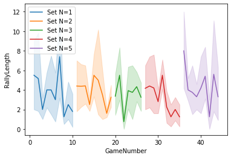

```python
for n, grp in df_features.groupby('SetNumber'):
    sns.lineplot(x = "GameNumber", y = "RallyLength", data=grp[['RallyLength','GameNumber','Server']], label="Set N="+str(n))
```

```python
df_features['RallyCategory'] = [ 0 if x.RallyLength == 0 else 1 if x.RallyLength <= 6 else 2 if x.RallyLength <= 12 else 3 for i,x in df_features.iterrows()]
```

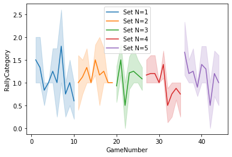

```python
for n, grp in df_features.groupby('SetNumber'):
    sns.lineplot(x = "GameNumber", y = "RallyCategory", data=grp[['RallyCategory','GameNumber','Server']], label="Set N="+str(n))
```

- NB ⛳ :  
  Now that we Extracted as much features as we can from the data (Ignore the string Data later in Observation/feature selection we will Label Encode it, or OneHot Encode it...) Now we will more to observation.

## **III.** 🔎 **Observation**

```python
df_exploration = df_features.copy()
```

### 📋 keeping track of Points during the Match

```python
df_points = df_exploration[['Server', "PointWinner", "PointNumber"]]
df_points['NadalPoints']=[df_points['PointWinner'][:i+1].value_counts()['RafaelNadal'] for i,x in df_points.iterrows()]
df_points['FedererPoints']=[df_points['PointWinner'][:i+1].value_counts()['RogerFederer'] if('RogerFederer' in df_points['PointWinner'][:i+1].value_counts()) else(0) for i,x in df_points.iterrows()]
```

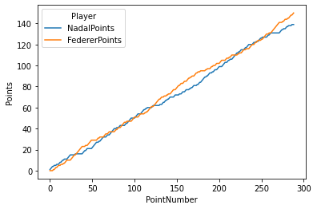

```python
sns.lineplot('PointNumber', 'Points', hue='Player', data=pd.melt(df_points[['NadalPoints','FedererPoints', 'PointNumber']], 'PointNumber', var_name='Player', value_name='Points'))
```

### 📈 Some Stats of the match

```python
df_exploration.columns
```

```
Index(['Server', 'Sets1', 'Sets2', 'Games1', 'Games2', 'Points1', 'Points2',
       'Points1Normalized', 'Points2Normalized', '1stService', '2ndService',
       'RelevantService', 'ServicesNumber', 'RallyLength', 'PointsCushion',
       'FinishType', '1stServiceType', '2ndServiceType', 'RelevantServiceType',
       'Fault', 'Error', 'PointWinner', 'ServerWins', 'GamePoint',
       'BreakPoint', 'Break', 'BreakSaved', 'PointNumber', 'GameNumber',
       'SetNumber', 'GameWinner', 'SetWinner', 'MatchWinner', 'ServerFault',
       'RallyCategory'],
      dtype='object')
```

```
p_Federer(winning any given point) =  0.5190311418685121 %
p_Nadal(winning any given point) =  0.4809688581314879 %
```

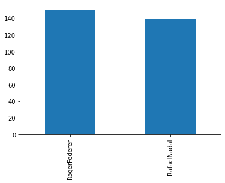

```python
p_Federer = df_exploration['PointWinner'].value_counts()['RogerFederer']/len(df_exploration['PointWinner'])
p_Nadal = df_exploration['PointWinner'].value_counts()['RafaelNadal']/len(df_exploration['PointWinner'])
print("p_Federer(winning any given point) = ", p_Federer, "%");
print("p_Nadal(winning any given point) = ", p_Nadal, "%");
pd.value_counts(df_exploration['PointWinner']).plot.bar()
```

```
Roger Federer Serve Wins in Match =  65.94202898550725 %
Roger Federer Serve Lost in Match =  34.05797101449275 %
```

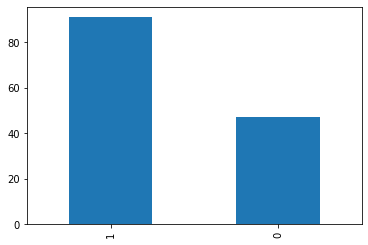

```python
print("Roger Federer Serve Wins in Match = ",(pd.value_counts(df_exploration[df_exploration['Server']=='RogerFederer']['ServerWins'])[1]*100/pd.value_counts(df_exploration[df_exploration['Server']=='RogerFederer']['ServerWins']).sum()), "%")
print("Roger Federer Serve Lost in Match = ",(pd.value_counts(df_exploration[df_exploration['Server']=='RogerFederer']['ServerWins'])[0]*100/pd.value_counts(df_exploration[df_exploration['Server']=='RogerFederer']['ServerWins']).sum()), "%")

pd.value_counts(df_exploration[df_exploration['Server']=='RogerFederer']['ServerWins']).plot.bar()
```

```
Rafael Nadal Serve Wins in Match =  60.9271523178808 %
Rafael Nadal Serve Lost in Match =  39.0728476821192 %
```

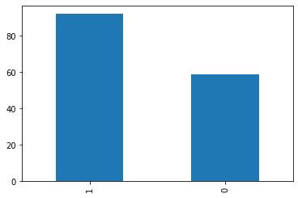

```python
print("Rafael Nadal Serve Wins in Match = ",(pd.value_counts(df_exploration[df_exploration['Server']=='RafaelNadal']['ServerWins'])[1]*100/pd.value_counts(df_exploration[df_exploration['Server']=='RafaelNadal']['ServerWins']).sum()), "%")
print("Rafael Nadal Serve Lost in Match = ",(pd.value_counts(df_exploration[df_exploration['Server']=='RafaelNadal']['ServerWins'])[0]*100/pd.value_counts(df_exploration[df_exploration['Server']=='RafaelNadal']['ServerWins']).sum()), "%")
pd.value_counts(df_exploration[df_exploration['Server']=='RafaelNadal']['ServerWins']).plot.bar()
```

##### - How many games Roger Federer and Rafael Nadal Won on this match

```python
pd.value_counts(df_exploration.groupby(['GameNumber', 'GameWinner']).size().reset_index(name='counts')['GameWinner'])
```

```
RogerFederer    24
RafaelNadal     20
Name: GameWinner, dtype: int64
```

##### How many games Roger Federer and Rafael Nadal Won/Lost when he started the serve

```python
print("Roger Federer Won", pd.value_counts(df_exploration[df_exploration['Server']=='RogerFederer'].groupby(['GameNumber', 'GameWinner']).size().reset_index(name='counts')['GameWinner'])['RogerFederer'], "Games When He started the serve")
print("Roger Federer Lost", pd.value_counts(df_exploration[df_exploration['Server']=='RogerFederer'].groupby(['GameNumber', 'GameWinner']).size().reset_index(name='counts')['GameWinner'])['RafaelNadal'], "Games When He started the serve")
```

```
Roger Federer Won 18 Games When He started the serve
Roger Federer Lost 4 Games When He started the serve
```

```python
print("Rafael Nadal Won", pd.value_counts(df_exploration[df_exploration['Server']=='RafaelNadal'].groupby(['GameNumber', 'GameWinner']).size().reset_index(name='counts')['GameWinner'])['RafaelNadal'], "Games When He started the serve")
print("Rafael Nadal Lost", pd.value_counts(df_exploration[df_exploration['Server']=='RafaelNadal'].groupby(['GameNumber', 'GameWinner']).size().reset_index(name='counts')['GameWinner'])['RogerFederer'], "Games When He started the serve")
```

```
Rafael Nadal Won 16 Games When He started the serve
Rafael Nadal Lost 6 Games When He started the serve
```

##### How many Faults Roger Federer and Rafael Nadal Won/Lost made.

```python
print("Rafael Nadal Made",pd.value_counts(df_exploration[df_exploration['Server']=='RafaelNadal']['ServerFault'])[1],"Faults in this Match")
print("Roger Federer Made",pd.value_counts(df_exploration[df_exploration['Server']=='RogerFederer']['ServerFault'])[1],"Faults in this Match")
```

```
Rafael Nadal Made 18 Faults in this Match
Roger Federer Made 27 Faults in this Match
```

##### How many Faults Roger Federer and Rafael Nadal Won/Lost made by game.

```python
print("Roger Federer Made counts Faults by Game:")
df_exploration[(df_exploration['Server']=='RogerFederer') & (df_exploration['ServerFault']==1)].groupby(['GameNumber', 'ServerFault']).size().reset_index(name='counts')
```

```
Roger Federer Made counts Faults by Game:
```

|  | GameNumber | ServerFault | counts |
| --- | --- | --- | --- |
| 0 | 2 | 1 | 2 |
| 1 | 4 | 1 | 1 |
| 2 | 12 | 1 | 3 |
| 3 | 16 | 1 | 2 |
| 4 | 20 | 1 | 3 |
| 5 | 26 | 1 | 4 |
| 6 | 30 | 1 | 2 |
| 7 | 32 | 1 | 3 |
| 8 | 34 | 1 | 1 |
| 9 | 36 | 1 | 3 |
| 10 | 44 | 1 | 3 |

```python
print("Rafael Nadal Made counts Faults by Game:")
df_exploration[(df_exploration['Server']=='RafaelNadal') & (df_exploration['ServerFault']==1)].groupby(['GameNumber', 'ServerFault']).size().reset_index(name='counts')
```

```
Rafael Nadal Made counts Faults by Game:
```

|  | GameNumber | ServerFault | counts |
| --- | --- | --- | --- |
| 0 | 3 | 1 | 1 |
| 1 | 7 | 1 | 1 |
| 2 | 9 | 1 | 2 |
| 3 | 13 | 1 | 3 |
| 4 | 15 | 1 | 1 |
| 5 | 21 | 1 | 2 |
| 6 | 23 | 1 | 2 |
| 7 | 25 | 1 | 1 |
| 8 | 27 | 1 | 1 |
| 9 | 31 | 1 | 1 |
| 10 | 39 | 1 | 1 |
| 11 | 43 | 1 | 2 |

## **IV.** 📈 **Features selection &** 🤖 **Modeling Phase**

### **Markov Model** (Prediction server winning a single game by point)

I choosed by game and not by Match because our dataset is very limited even for Games, and I see that prediction by Game will result in by Set and than by Match.(the First methode we will use is based on statistics and pure probability)

- calculate the probability of server winning a single game,
- given p(winning single point) and current point score

```python
# Basic Math Functions
def fact(x):
    if x in [0, 1]:  return 1
    r = 1
    for a in range(1, (int(x)+1)):  r = r*a
    return r

def ch(a, b):
    return fact(a)/(fact(b)*fact(a-b))
```

```python
def gameProbability(s, a, b):
    return ch((a+b), a)*(s**a)*((1-s)**b)*s
```

```python
def gameProb(s, s_p1=0, s_p2=0):
    ## s_p1, s_p2 = current game score, where love = 0, 15 = 1, etc.
    ## - e.g. 30-15 is s_p1=2, s_p2=1

    ## check if game is already finished:
    if s_p1 >= 4 and (s_p1-s_p2) >= 2:
        return 1
    elif s_p2 >= 4 and (s_p2-s_p1) >= 2:
        return 0
    else:   pass
    ## if deuce or ad score e.g. 5-4, reduce to e.g. 3-2
    while True:
        if (s_p1+s_p2) > 6:
            s_p1 -= 1
            s_p2 -= 1
        else:   break
    ## specific probabilities:
    if s_p2 == 0:  s_p20 = gameProbability(s, 3-s_p1, 0)
    else:   s_p20 = 0
    if s_p2 <= 1:  s_p215 = gameProbability(s, 3-s_p1, 1-s_p2)
    else:   s_p215 = 0
    if s_p2 <= 2:  s_p230 = gameProbability(s, 3-s_p1, 2-s_p2)
    else:   s_p230 = 0
    if s_p1 == 4:
        s_p2Ad, lAd = s, 0
        d = 1-s
    elif s_p2 == 4:
        s_p2Ad, lAd = 0, 1-s
        d = s
    else:
        s_p2Ad, lAd = 0, 0
        a = 3 - s_p1
        b = 3 - s_p2
        d = ch((a+b), a)*(s**a)*((1-s)**b)
    if s_p1 <= 2:  l30 = gameProbability((1-s), 3-s_p2, 2-s_p1)
    else:   l30 = 0
    if s_p1 <= 1:  l15 = gameProbability((1-s), 3-s_p2, 1-s_p1)
    else:   l15 = 0
    if s_p1 == 0:  l0 = gameProbability((1-s), 3-s_p2, 0)
    else:   l0 = 0
    ## given d = prob of getting to deuce,
    ## math to divide up further gameProbability
    dv = s**2 + (1-s)**2
    s_p2d = (d*(s**2))/dv
    ld = (d*((1-s)**2))/dv
    win = s_p20 + s_p215 + s_p230 + s_p2d + s_p2Ad
    lose = l0 + l15 + l30 + ld + lAd
    return win
```

Adding These two infos to Exploration DataFrame

```python
df_exploration["probability_of_wining_a_game"] = [gameProb(p_Federer, s_p1=int(x.Points1Normalized), s_p2=int(x.Points2Normalized)) if(x.ServerWins == 'RogerFederer') else gameProb(p_Nadal, s_p1=int(x.Points1Normalized), s_p2=int(x.Points2Normalized)) for i,x in df_exploration.iterrows()]
df_exploration["Opponenet_probability_of_wining_a_game"] = [1-x.probability_of_wining_a_game for i,x in df_exploration.iterrows()]
```

```python
df_exploration[["Server","probability_of_wining_a_game","Opponenet_probability_of_wining_a_game"]].head(5)
```

|  | Server | probability_of_wining_a_game | Opponenet_probability_of_wining_a_game |
| --- | --- | --- | --- |
| 0 | RafaelNadal | 0.452525 | 0.547475 |
| 1 | RafaelNadal | 0.613785 | 0.386215 |
| 2 | RafaelNadal | 0.782702 | 0.217298 |
| 3 | RafaelNadal | 0.924774 | 0.075226 |
| 4 | RogerFederer | 0.452525 | 0.547475 |

```python
df_exploration["RF_P"] = [x.probability_of_wining_a_game if x.Server == "RogerFederer" else x.Opponenet_probability_of_wining_a_game for i,x in df_exploration.iterrows()]
df_exploration["RN_P"] = [x.probability_of_wining_a_game if x.Server == "RafaelNadal" else x.Opponenet_probability_of_wining_a_game for i,x in df_exploration.iterrows()]
```

```
RogerFederer probability of Games During the Match
```

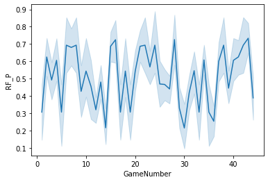

```python
print('RogerFederer probability of Games During the Match')
sns.lineplot(x = "GameNumber", y = "RF_P", data=df_exploration[['RF_P','GameNumber','Server']])
```

```
Rafael Nadal probability of Games During the Match
```

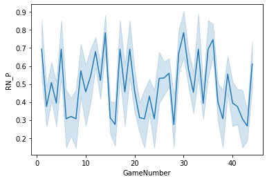

```python
print('Rafael Nadal probability of Games During the Match')
sns.lineplot(x = "GameNumber", y = "RN_P", data=df_exploration[['RN_P','GameNumber','Server']])
```

```python
df_exploration[['RN_P',"Points1","Points2",'GameWinner','Server']].tail(5)
```

|  | RN_P | Points1 | Points2 | GameWinner | Server |
| --- | --- | --- | --- | --- | --- |
| 284 | 0.777796 | 30 | 40 | RogerFederer | RogerFederer |
| 285 | 0.538007 | 40 | 40 | RogerFederer | RogerFederer |
| 286 | 0.279243 | AD | 40 | RogerFederer | RogerFederer |
| 287 | 0.538007 | 40 | 40 | RogerFederer | RogerFederer |
| 288 | 0.279243 | AD | 40 | RogerFederer | RogerFederer |

> As we Can see from the graphs and also from the table above, some games didn't turn out like our calculations, and some did.

### **Features Selection and Data Encoding**

```python
print("*****************************************************************")
print("***                  All Features we Have                     ***")
print("*****************************************************************")
for feature in df_features.columns:
  print("'"+feature+"',")
```

```
***                  All Features we Have                     ***
'Server',
'Sets1',
'Sets2',
'Games1',
'Games2',
'Points1',
'Points2',
'Points1Normalized',
'Points2Normalized',
'1stService',
'2ndService',
'RelevantService',
'ServicesNumber',
'RallyLength',
'PointsCushion',
'FinishType',
'1stServiceType',
'2ndServiceType',
'RelevantServiceType',
'Fault',
'Error',
'PointWinner',
'ServerWins',
'GamePoint',
'BreakPoint',
'Break',
'BreakSaved',
'PointNumber',
'GameNumber',
'SetNumber',
'GameWinner',
'SetWinner',
'MatchWinner',
'ServerFault',
'RallyCategory',
```

We will remove 🚨 :

- Points1 and Points2 because it's already represented by Points1Normalized and Points2Normalized
- 1stService, 2ndService, and RelevantService because we extracted from them the infos we need already.
- Fault because I used it just to get the ServerFault feature and it may just pollute the data.
- 1stServiceType and 2ndServiceType are resumed in the RelevantServiceType feature which means it's a redundant data.

```python
features_to_remove = ['Points1',
                      'Points2',
                      '1stService',
                      '2ndService',
                      'RelevantService',
                      '1stServiceType',
                      '2ndServiceType',
                      'Fault']
```

```python
df_afterRemove = df_features.drop(features_to_remove,'columns').copy()
print("*****************************************************************")
print("***                 Features After Remove                     ***")
print("*****************************************************************")
df_afterRemove.info()
```

```
***                 Features After Remove                     ***
<class 'pandas.core.frame.DataFrame'>
RangeIndex: 289 entries, 0 to 288
Data columns (total 27 columns):
 #   Column               Non-Null Count  Dtype
---  ------               --------------  -----
 0   Server               289 non-null    object
 1   Sets1                289 non-null    int64
 2   Sets2                289 non-null    int64
 3   Games1               289 non-null    int64
 4   Games2               289 non-null    int64
 5   Points1Normalized    289 non-null    int64
 6   Points2Normalized    289 non-null    int64
 7   ServicesNumber       289 non-null    int64
 8   RallyLength          289 non-null    int64
```

[output cut: 20 more lines]

```python
outcomes = ['PointWinner',
            'GameWinner',
            'SetWinner',
            'MatchWinner']
```

> **Label Encoding**

| Server | FinishType | RelevantServiceType | PointWinner | GameWinner | SetWinner | MatchWinner |
| --- | --- | --- | --- | --- | --- | --- |
| 'RafaelNadal': 1 'RogerFederer': 2 | 'double_fault':1 'unforced_error':2 'forced_error':3 'winner':4 'service_winner':5 'ace':6 | 'to_body': 1 'wide': 2 'down_the_T': 3 | 'RafaelNadal': 1 'RogerFederer': 2 | 'RafaelNadal': 1 'RogerFederer': 2 | 'RafaelNadal': 1 'RogerFederer': 2 | 'RafaelNadal': 1 'RogerFederer': 2 |

🔺 **'RafaelNadal': 1** \ 🔺 **'RogerFederer': 2**

```python
#Clean Up
df_afterRemove["RelevantServiceType"] = [x.RelevantServiceType.lstrip().replace(" ","_") for i,x in df_afterRemove.iterrows()]
df_afterRemove["FinishType"] = [x.FinishType.lstrip().replace(" ","_") for i,x in df_afterRemove.iterrows()]
print(df_afterRemove["FinishType"].unique())
print(df_afterRemove["RelevantServiceType"].unique())
```

```
['forced_error' 'unforced_error' 'winner' 'double_fault' 'ace'
 'service_winner']
['to_body' 'wide' 'down_the_T']
```

```python
df_label = df_afterRemove.copy()
```

```python
df_label['MatchWinner'] = [ 1 if x.MatchWinner == 'RafaelNadal' else 2 for i,x in df_label.iterrows()]
df_label['SetWinner'] = [ 1 if x.SetWinner == 'RafaelNadal' else 2 for i,x in df_label.iterrows()]
df_label['GameWinner'] = [ 1 if x.GameWinner == 'RafaelNadal' else 2 for i,x in df_label.iterrows()]
df_label['PointWinner'] = [ 1 if x.PointWinner == 'RafaelNadal' else 2 for i,x in df_label.iterrows()]
df_label['Server'] = [ 1 if x.Server == 'RafaelNadal' else 2 for i,x in df_label.iterrows()]
```

```python
df_label['RelevantServiceType'] = [1 if x.RelevantServiceType == 'to_body' else 2 if  x.RelevantServiceType == 'wide' else 3 for i,x in df_label.iterrows()]
```

```python
df_label['FinishType'] = [1 if x.FinishType == 'double_fault' else 2 if  x.FinishType == 'unforced_error' else 3 if  x.FinishType == 'forced_error' else 4 if  x.FinishType == 'winner' else 5 if  x.FinishType == 'service_winner' else 6 for i,x in df_label.iterrows()]
```

```python
df_label[['MatchWinner','SetWinner','GameWinner','PointWinner','Server','RelevantServiceType','FinishType']].head(2)
```

|  | MatchWinner | SetWinner | GameWinner | PointWinner | Server | RelevantServiceType | FinishType |
| --- | --- | --- | --- | --- | --- | --- | --- |
| 0 | 2 | 2 | 1 | 1 | 1 | 1 | 3 |
| 1 | 2 | 2 | 1 | 1 | 1 | 2 | 2 |

```python
df_label.info()
```

```
<class 'pandas.core.frame.DataFrame'>
RangeIndex: 289 entries, 0 to 288
Data columns (total 27 columns):
 #   Column               Non-Null Count  Dtype
---  ------               --------------  -----
 0   Server               289 non-null    int64
 1   Sets1                289 non-null    int64
 2   Sets2                289 non-null    int64
 3   Games1               289 non-null    int64
 4   Games2               289 non-null    int64
 5   Points1Normalized    289 non-null    int64
 6   Points2Normalized    289 non-null    int64
 7   ServicesNumber       289 non-null    int64
 8   RallyLength          289 non-null    int64
 9   PointsCushion        289 non-null    int64
```

[output cut: 19 more lines]

##### **Data Cleaning**

###### # Missing data

It's time to check how many missing data each variable has.

```python
## check missing data
df_label.isnull().sum()
```

```
Server                 0
Sets1                  0
Sets2                  0
Games1                 0
Games2                 0
Points1Normalized      0
Points2Normalized      0
ServicesNumber         0
RallyLength            0
PointsCushion          0
FinishType             0
RelevantServiceType    0
Error                  0
PointWinner            0
ServerWins             0
GamePoint              0
BreakPoint             0
Break                  0
BreakSaved             0
PointNumber            0
GameNumber             0
SetNumber              0
GameWinner             0
SetWinner              0
MatchWinner            0
ServerFault            0
RallyCategory          0
dtype: int64
```

None is missing which is good.

#### **Correlations**

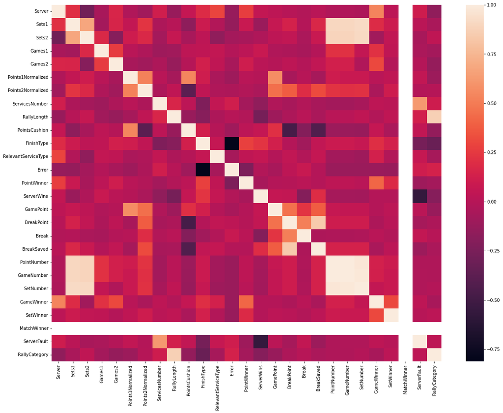

```python
plt.subplots(figsize=(20,15))
sns.heatmap(df_label.corr())
```

First of all we can notice that MatchWinner is out of discussion but it can be predicted using prediction of the game/set winner.

I will start with trying to classify the GameWinner which means i need to drop MatchWinner and SetWinner.

Let me add to this that Correlation does not mean causality by any means so even if some columns correlate it might mean nothing for our outcome. as an **exemple see the attached graph of (deaths in France / and search cout of the word "raclette" in France**

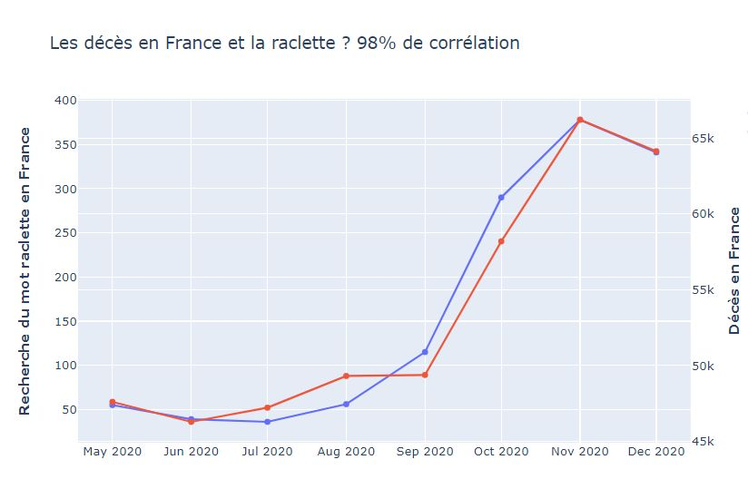

```python
df_label_game = df_label.drop(['SetWinner','MatchWinner'],'columns').copy()
df_label_game.columns
```

```
Index(['Server', 'Sets1', 'Sets2', 'Games1', 'Games2', 'Points1Normalized',
       'Points2Normalized', 'ServicesNumber', 'RallyLength', 'PointsCushion',
       'FinishType', 'RelevantServiceType', 'Error', 'PointWinner',
       'ServerWins', 'GamePoint', 'BreakPoint', 'Break', 'BreakSaved',
       'PointNumber', 'GameNumber', 'SetNumber', 'GameWinner', 'ServerFault',
       'RallyCategory'],
      dtype='object')
```

Scaling is not required

Scaling is done to Normalize data so that priority is not given to a particular feature. Role of Scaling is mostly important in algorithms that are distance based and require Euclidean Distance.

Random Forest is a tree-based model and hence does not require feature scaling.

This algorithm requires partitioning, even if you apply Normalization then also the result would be the same.

### Test-Train Split : GameWinner Label Encoding

To test the performances of our algorithms I will split the dataset into two distinct train and test sets.

```python
#Get Target data
y = df_label_game['GameWinner']

#Load X Variables into a Pandas Dataframe with columns
X = df_label_game.drop(['GameWinner'], axis = 1)
```

```python
print(f'X : {X.shape}')
```

```
X : (289, 24)
```

```python
from sklearn.model_selection import train_test_split
X_train, X_test, y_train, y_test = train_test_split(X, y, test_size=0.30, random_state=1234)
```

```python
print(f'X_train : {X_train.shape}')
print(f'y_train : {y_train.shape}')
print(f'X_test : {X_test.shape}')
print(f'y_test : {y_test.shape}')
```

```
X_train : (202, 24)
y_train : (202,)
X_test : (87, 24)
y_test : (87,)
```

## Fine-tune Random Forest : GameWinner Label Encoding

in this task we are trying to find the best Random Forest Model, basically our Idea is to try diffrent sets of parameters till we find the best model, this called hyperparametering:

### Build Random Forest Model with hyperparameters:

##### Grid Search

In this grid search I will try different combinations of RF hyperparameters.

Most important hyperparameters of Random Forest:

> n_estimators = n of trees

> max_features = max number of features considered for splitting a node

> max_depth = max number of levels in each decision tree

> min_samples_split = min number of data points placed in a node before the node is split

> min_samples_leaf = min number of data points allowed in a leaf node

> bootstrap = method for sampling data points (with or without replacement)

```python
# Number of trees in random forest
n_estimators = [int(x) for x in np.linspace(start = 10, stop = 80, num = 10)]
# Number of features to consider at every split
max_features = ['auto', 'sqrt']
# Maximum number of levels in tree
max_depth = [2,4]
# Minimum number of samples required to split a node
min_samples_split = [2, 5]
# Minimum number of samples required at each leaf node
min_samples_leaf = [1, 2]
# Method of selecting samples for training each tree
bootstrap = [True, False]
```

```python
# Create the param grid
param_grid = {'n_estimators': n_estimators,
               'max_features': max_features,
               'max_depth': max_depth,
               'min_samples_split': min_samples_split,
               'min_samples_leaf': min_samples_leaf,
               'bootstrap': bootstrap}
print(param_grid)
```

```
{'n_estimators': [10, 17, 25, 33, 41, 48, 56, 64, 72, 80], 'max_features': ['auto', 'sqrt'], 'max_depth': [2, 4], 'min_samples_split': [2, 5], 'min_samples_leaf': [1, 2], 'bootstrap': [True, False]}
```

Creating the Model

```python
from sklearn.ensemble import RandomForestClassifier
rf_Model = RandomForestClassifier()
```

Creating the Search Grid using our model

```python
from sklearn.model_selection import GridSearchCV
rf_Grid = GridSearchCV(estimator = rf_Model, param_grid = param_grid, cv = 3, verbose=2, n_jobs = 4)
```

Starting the look for the best model for our case of use.

```python
rf_Grid.fit(X_train, y_train)
```

```
Fitting 3 folds for each of 320 candidates, totalling 960 fits
```

```
GridSearchCV(cv=3, estimator=RandomForestClassifier(), n_jobs=4,
             param_grid={'bootstrap': [True, False], 'max_depth': [2, 4],
                         'max_features': ['auto', 'sqrt'],
                         'min_samples_leaf': [1, 2],
                         'min_samples_split': [2, 5],
                         'n_estimators': [10, 17, 25, 33, 41, 48, 56, 64, 72,
                                          80]},
             verbose=2)
```

```python
rf_Grid.best_params_
```

```
{'bootstrap': True,
 'max_depth': 4,
 'max_features': 'sqrt',
 'min_samples_leaf': 1,
 'min_samples_split': 5,
 'n_estimators': 80}
```

The best parameters to find the best model are :

## Performance : GameWinner Label Encoding

#### 1. Accuracy

```python
print (f'Train Accuracy - : {rf_Grid.score(X_train,y_train):.4f}')
print (f'Test Accuracy - : {rf_Grid.score(X_test,y_test):.4f}')
```

```
Train Accuracy - : 0.9703
Test Accuracy - : 0.9195
```

```python
results = rf_Grid.cv_results_
pred = rf_Grid.predict(X_test)
from sklearn import preprocessing
le = preprocessing.LabelEncoder()
pred = le.fit_transform(pred)
testdata = le.fit_transform(y_test)
```

#### 2. AUC - ROC Curve

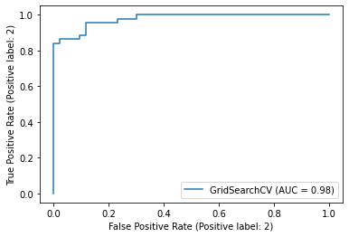

```python
from sklearn.metrics import plot_roc_curve, auc
import matplotlib.pyplot as plt

rf_disp = plot_roc_curve(rf_Grid, X_test, y_test)
plt.show()
```

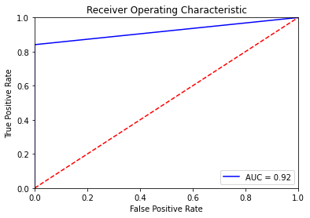

```python
from sklearn import metrics
fpr, tpr, threshold = metrics.roc_curve(testdata, pred)
roc_auc = metrics.auc(fpr, tpr)

# plt Methode 1
import matplotlib.pyplot as plt
plt.title('Receiver Operating Characteristic')
plt.plot(fpr, tpr, 'b', label = 'AUC = %0.2f' % roc_auc)
plt.legend(loc = 'lower right')
plt.plot([0, 1], [0, 1],'r--')
plt.xlim([0, 1])
plt.ylim([0, 1])
plt.ylabel('True Positive Rate')
plt.xlabel('False Positive Rate')
plt.show()
```

#### 3. Evaluation Results

```python
# Evaluating the Algorithm
from sklearn import metrics
print('Mean Absolute Error:', metrics.mean_absolute_error(testdata, pred))
print('Mean Squared Error:', metrics.mean_squared_error(testdata, pred))
print('Root Mean Squared Error:', np.sqrt(metrics.mean_squared_error(testdata, pred)))
print('AUC et ROC :', metrics.roc_auc_score(testdata, pred))
```

```
Mean Absolute Error: 0.08045977011494253
Mean Squared Error: 0.08045977011494253
Root Mean Squared Error: 0.2836543144655877
AUC et ROC : 0.9204545454545454
```

#### **Decision Tree**

```python
# import DecisionTreeClassifier

from sklearn.tree import DecisionTreeClassifier
```

# Decision Tree Classifier with criterion gini index

```python
# instantiate the DecisionTreeClassifier model with criterion gini index

clf_gini = DecisionTreeClassifier(criterion='gini', max_depth=3, random_state=0)


# fit the model
clf_gini.fit(X_train, y_train)
```

```
DecisionTreeClassifier(max_depth=3, random_state=0)
```

```python
y_pred_gini = clf_gini.predict(X_test)
y_pred_gini
```

```
array([1, 1, 2, 1, 2, 2, 1, 2, 1, 1, 1, 1, 2, 1, 2, 2, 2, 2, 1, 2, 1, 2,
       2, 1, 2, 1, 1, 1, 1, 1, 2, 1, 1, 1, 1, 2, 1, 2, 2, 1, 1, 1, 1, 1,
       1, 1, 1, 1, 1, 1, 1, 1, 1, 2, 2, 1, 2, 1, 1, 1, 2, 1, 2, 1, 2, 2,
       1, 2, 2, 1, 1, 2, 2, 2, 2, 1, 2, 2, 2, 1, 1, 1, 1, 2, 2, 2, 1])
```

```python
from sklearn.metrics import accuracy_score
#score for test data
print('Model accuracy score with criterion gini index: {0:0.4f}'. format(accuracy_score(y_test, y_pred_gini)))
```

```
Model accuracy score with criterion gini index: 0.8391
```

```python
y_pred_train_gini = clf_gini.predict(X_train)

y_pred_train_gini
```

```
array([2, 1, 2, 2, 1, 1, 2, 1, 2, 2, 2, 1, 2, 2, 1, 2, 1, 2, 2, 2, 1, 1,
       2, 2, 1, 2, 1, 1, 2, 1, 2, 2, 2, 1, 1, 2, 1, 2, 1, 2, 1, 1, 2, 2,
       1, 1, 1, 2, 1, 1, 1, 1, 1, 1, 2, 1, 1, 1, 2, 2, 2, 2, 1, 2, 2, 1,
       2, 2, 2, 2, 1, 2, 1, 1, 2, 2, 2, 2, 1, 2, 1, 2, 2, 2, 1, 2, 1, 2,
       2, 1, 1, 1, 1, 1, 2, 2, 1, 2, 2, 2, 1, 1, 1, 2, 2, 2, 1, 1, 1, 1,
       2, 2, 2, 2, 2, 1, 1, 2, 1, 1, 1, 1, 1, 1, 1, 1, 1, 1, 2, 2, 1, 2,
       2, 2, 2, 1, 1, 2, 1, 1, 2, 2, 1, 2, 1, 2, 2, 2, 2, 1, 2, 2, 1, 1,
       2, 1, 1, 1, 2, 2, 1, 2, 2, 1, 1, 2, 2, 2, 1, 2, 2, 1, 2, 1, 1, 2,
       2, 1, 2, 2, 1, 1, 1, 1, 2, 1, 1, 1, 1, 2, 2, 2, 1, 2, 1, 2, 1, 2,
       1, 1, 1, 2])
```

```python
#score for train data
print('Training-set accuracy score: {0:0.4f}'. format(accuracy_score(y_train, y_pred_train_gini)))
```

```
Training-set accuracy score: 0.9109
```

```python
print('Training set score: {:.4f}'.format(clf_gini.score(X_train, y_train)))

print('Test set score: {:.4f}'.format(clf_gini.score(X_test, y_test)))
```

```
Training set score: 0.9109
Test set score: 0.8391
```

```
[Text(306.90000000000003, 380.52, 'X[0] <= 1.5\ngini = 0.494\nsamples = 202\nvalue = [90, 112]'),
```

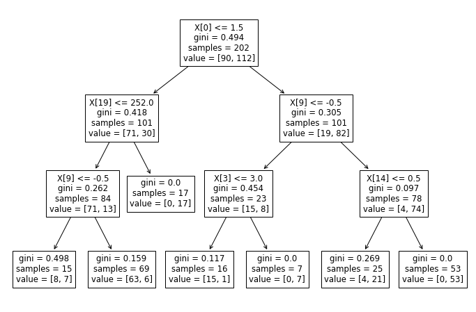

```python
plt.figure(figsize=(12,8))

from sklearn import tree

tree.plot_tree(clf_gini.fit(X_train, y_train))
```

```python
import graphviz
dot_data = tree.export_graphviz(clf_gini, out_file=None,
                              feature_names=X_train.columns,
                              class_names=[str(x) for x in y_train],
                              filled=True, rounded=True,
                              special_characters=True)

graph = graphviz.Source(dot_data)

graph
```

[figure not shown]

# Decision Tree Classifier with criterion entropy

```python
# instantiate the DecisionTreeClassifier model with criterion entropy

clf_en = DecisionTreeClassifier(criterion='entropy', max_depth=3, random_state=0)

# fit the model
clf_en.fit(X_train, y_train)
```

```
DecisionTreeClassifier(criterion='entropy', max_depth=3, random_state=0)
```

```python
y_pred_en = clf_en.predict(X_test)
```

```python
from sklearn.metrics import accuracy_score

print('Model accuracy score with criterion entropy: {0:0.4f}'. format(accuracy_score(y_test, y_pred_en)))
```

```
Model accuracy score with criterion entropy: 0.8391
```

```python
y_pred_train_en = clf_en.predict(X_train)

y_pred_train_en
```

```
array([2, 1, 2, 2, 1, 1, 2, 1, 2, 2, 2, 1, 2, 2, 1, 2, 1, 2, 2, 2, 1, 1,
       2, 2, 1, 2, 1, 1, 2, 1, 2, 2, 2, 1, 1, 2, 1, 2, 1, 2, 1, 1, 2, 2,
       1, 1, 1, 2, 1, 1, 1, 1, 1, 1, 2, 1, 1, 1, 2, 2, 2, 2, 1, 2, 2, 1,
       2, 2, 2, 2, 1, 2, 1, 1, 2, 2, 2, 2, 1, 2, 1, 2, 2, 2, 1, 2, 1, 2,
       2, 1, 1, 1, 1, 1, 2, 2, 1, 2, 2, 2, 1, 1, 1, 2, 2, 2, 1, 1, 1, 1,
       2, 2, 2, 2, 2, 1, 1, 2, 1, 1, 1, 1, 1, 1, 1, 1, 1, 1, 2, 2, 1, 2,
       2, 2, 2, 1, 1, 2, 1, 1, 2, 2, 1, 2, 1, 2, 2, 2, 2, 1, 2, 2, 1, 1,
       2, 1, 1, 1, 2, 2, 1, 2, 2, 1, 1, 2, 2, 2, 1, 2, 2, 1, 2, 1, 1, 2,
       2, 1, 2, 2, 1, 1, 1, 1, 2, 1, 1, 1, 1, 2, 2, 2, 1, 2, 1, 2, 1, 2,
       1, 1, 1, 2])
```

```python
# print the scores on training and test set

print('Training set score: {:.4f}'.format(clf_en.score(X_train, y_train)))

print('Test set score: {:.4f}'.format(clf_en.score(X_test, y_test)))
```

```
Training set score: 0.9109
Test set score: 0.8391
```

```
[Text(306.90000000000003, 380.52, 'X[0] <= 1.5\nentropy = 0.991\nsamples = 202\nvalue = [90, 112]'),
```

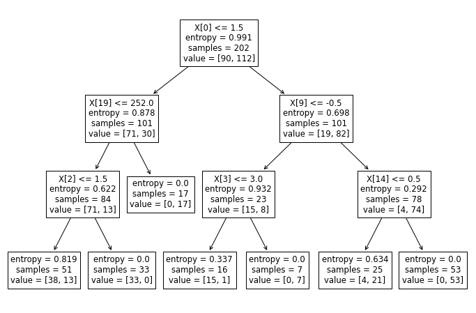

```python
plt.figure(figsize=(12,8))

from sklearn import tree

tree.plot_tree(clf_en.fit(X_train, y_train))
```

```python
import graphviz

dot_data = tree.export_graphviz(clf_en, out_file=None,
                              feature_names=X_train.columns,
                              class_names=[str(x) for x in y_train],
                              filled=True, rounded=True,
                              special_characters=True)

graph = graphviz.Source(dot_data)

graph
```

[figure not shown]

# KNeighbors Classifier

```python
#KNeighbors Classifier

from sklearn.neighbors import KNeighborsClassifier

knn = KNeighborsClassifier(n_neighbors = 2)
knn.fit(X_train, y_train)
y_pred = knn.predict(X_test)

# print the scores on training and test set
print('Training set score: {:.4f}'.format(knn.score(X_train, y_train)))

print('Test set score: {:.4f}'.format(knn.score(X_test, y_test)))
```

```
Training set score: 0.9752
Test set score: 0.9195
```

# Logistic Regression

```python
from sklearn.linear_model import LogisticRegression

LR_clf = LogisticRegression()
```

```python
LR_clf.fit(X_train, y_train)
```

```
LogisticRegression()
```

```python
print('Accuracy of Logistic regression classifier on training set: {:.2f}'
     .format(LR_clf.score(X_train, y_train)))
print('Accuracy of Logistic regression classifier on test set: {:.2f}'
     .format(LR_clf.score(X_test, y_test)))
```

```
Accuracy of Logistic regression classifier on training set: 0.79
Accuracy of Logistic regression classifier on test set: 0.78
```

# Support Vector Machines (SVM)

```python
from sklearn.svm import SVC
svc_clf = SVC().fit(X_train, y_train)

print('Accuracy of Support Vector classifier on training set: {:.2f}'
     .format(svc_clf.score(X_train, y_train)))
print('Accuracy of Support Vector classifier on test set: {:.2f}'
     .format(svc_clf.score(X_test, y_test)))
```

```
Accuracy of Support Vector classifier on training set: 0.57
Accuracy of Support Vector classifier on test set: 0.46
```

# Voting classifiers:

In machine learning, we often achieve better performance by ensembling various classifiers predict a final output.

We implement the ensemble for the voting classifiers using sklearn.ensemble.VotingClassifier. First, we use the option of 'hard' voting that uses majority rule voting.

```python
from sklearn.ensemble import VotingClassifier

eclf1 = VotingClassifier(estimators=[('lr', LR_clf),
            ('en', clf_en), ('knn', knn),
            ('gini', clf_gini), ('svc', svc_clf), ('rf', rf_Grid)],
            voting='hard')

eclf1 = eclf1.fit(X_train, y_train)
```

```
Fitting 3 folds for each of 320 candidates, totalling 960 fits
```

```python
print('Accuracy of VotingClassifier classifier on training set: {:.2f}'
     .format(eclf1.score(X_train, y_train)))
print('Accuracy of VotingClassifier classifier on test set: {:.2f}'
     .format(eclf1.score(X_test, y_test)))
```

```
Accuracy of VotingClassifier classifier on training set: 0.94
Accuracy of VotingClassifier classifier on test set: 0.87
```

# **V.** 🚀 **Further improvements**

- Try OneHot Encoding
- instead of extracting and defining features, we can Vectorise **The description Text** and use the features extracted automatically.
- Try to use deep learning for text classification **Convolutional Neural Networks (CNN) and Recurrent Neural Networks (RNN)**

# **References:**

[Applied Machine Learning in Python](https://www.coursera.org/learn/python-machine-learning?specialization=data-science-python) course by University of Michigan in Coursera

[Python Code for Tennis Markov](https://summerofjeff.wordpress.com/2011/01/13/python-code-for-tennis-markov/)

[Machine Learning for the Prediction of Professional Tennis Matches](https://www.doc.ic.ac.uk/teaching/distinguished-projects/2015/m.sipko.pdf)

[An algorithm that can predict the unpredictable](https://www.serveplus.one/blog/how-i-built-this)

[Starter: Tennis Match Charting Project](https://www.kaggle.com/kerneler/starter-tennis-match-charting-project-b20e1116-1)